# Exploratory Data Analysis: MasterControl QAL Lead Progression (Mx vs Qx)

Amiya Ranjan Sahoo

March 19, 2026

```r
knitr::opts_chunk$set(
  echo = TRUE,
  warning = FALSE,
  message = FALSE
)
```

# 1 1. Introduction

MasterControl provides enterprise software solutions to life sciences organizations through two primary product lines: Qx, focused on quality management systems, and Mx, designed to support manufacturing operations. While Qx has demonstrated strong market performance with higher lead progression rates, Mx has consistently underperformed relative to the company baseline.

The objective of this exploratory data analysis (EDA) is to examine the structure, quality, and characteristics of the QAL (Qualified Account Lead) dataset to better understand the underlying patterns associated with lead progression. In particular, this analysis focuses on identifying differences in progression behavior across product lines, industries, manufacturing models, organizational tiers, and buyer personas.

This EDA serves as the foundational phase of the data mining process. The primary goals of this stage are: • To understand the overall shape and structure of the dataset • To assess data quality, including missing values and duplicate records • To evaluate variable distributions and category imbalance • To examine lead progression behavior across segments • To prepare a clean and modeling-ready dataset

The insights derived from this analysis will guide the development of a predictive modeling framework aimed at improving conversion performance for the Mx product line and supporting more targeted outbound strategies.

# 2 2. Business Problem Statement

MasterControl provides enterprise software solutions to life sciences organizations through two primary product lines: Qx, focused on quality management systems, and Mx, focused on manufacturing operations. While Qx demonstrates strong market adoption and a higher lead progression rate, the Mx product line underperforms relative to the company benchmark.

Despite being strategically important for growth, Mx currently converts qualified leads at a significantly lower rate compared to Qx. The organization lacks clear visibility into: • Which industries are most suitable for Mx • Which manufacturing models demonstrate stronger conversion • Which company tiers or territories yield better outcomes • Which buyer personas (job titles and functions) are true decision-makers for manufacturing solutions

As a result, outbound prospecting efforts may be broadly distributed across accounts that are not ideal candidates for Mx, reducing sales efficiency and overall conversion performance.

The purpose of this analysis is to establish a data-driven understanding of lead progression patterns and identify characteristics that differentiate converting versus non-converting leads. This exploratory phase supports the development of a predictive framework that can guide improved targeting and segmentation strategies for the Mx product line.

# 3 3. Data Description

The dataset used in this analysis contains Qualified Account Lead (QAL) records spanning 2024–2025. Each row represents a lead interaction associated with a specific account and product solution.

## 3.1 3.1 Dataset Overview

```
•   Observations: 16,644 rows
•   Variables: 14 columns
•   Data Type: Primarily categorical variables with one cohort date variable
•   Target Variable: Lead progression (derived from sales stage advancement)
```

## 3.2 3.2 Key Variables

Account Characteristics • acct_target_industry: Industry classification • acct_manufacturing_model: Type of manufacturing model • acct_primary_site_function: Core functional role of the site • acct_tier_rollup: Account size or strategic tier • acct_territory_rollup: Geographic segmentation

Contact Information • contact_lead_title: Job title of the lead • contact_lead_id: Unique identifier for the contact

Campaign & Priority Variables • last_tactic_campaign_channel: Marketing channel source • priority: Lead priority classification

Identifiers • qal_id: Unique identifier for each QAL record • qal_cohort_date: Date associated with the lead cohort

## 3.3 3.3 Target Variable Construction

Lead progression is defined as advancement to SQL (Sales Qualified Lead) or beyond (SQL, SQO, Won). A binary variable (progressed) will be created where: • 1 = Lead progressed • 0 = Lead did not progress

This definition aligns with the business objective of improving movement to advanced sales stages and enables binary classification modeling in subsequent phases.

# 4 4.Loading Libraries

```r
# ---------------------------
# Data Import & Manipulation
# ---------------------------
library(readr)        # Reading CSV files
library(dplyr)        # Data manipulation
library(tidyr)        # Data reshaping
library(tibble)       # Modern data frames
library(stringr)      # String processing
library(forcats)      # Factor handling
library(gt)           # For professional formatted tables

# ---------------------------
# Data Cleaning & Summary
# ---------------------------
library(janitor)      # Clean column names
library(skimr)        # Detailed summary statistics
library(lubridate)    # Date handling

# ---------------------------
# Missing Data Analysis
# ---------------------------
library(naniar)       # Missing data visualization

# ---------------------------
# Visualization
# ---------------------------
library(ggplot2)      # Core visualization package
library(scales)       # Percent formatting
library(ggthemes)     # Professional plot themes
library(gridExtra)    # Arranging multiple plots

# ---------------------------
# Categorical Association
# ---------------------------

library(rcompanion)   # Cramer's V for categorical correlation

# Global Plot Theme
theme_set(theme_minimal())

set.seed(123)
```

# 5 5. Loading Dataset

```r
# Read CSV file
qal_data <- read_csv("Mastercontrol QAL Performance.csv") %>%
  clean_names()
```

## 5.1 5.1 Inspecting the dataset

```r
# 1. Dimensions

dim_table <- data.frame(
  Metric = c("Number of Rows", "Number of Columns"),
  Value = c(nrow(qal_data), ncol(qal_data))
)

gt(dim_table)
```

| Metric | Value |
| --- | --- |
| Number of Rows | 16644 |
| Number of Columns | 14 |

```r
# 2. Column Names
col_table <- data.frame(
  Column_Names = colnames(qal_data)
)

gt(col_table)
```

| Column_Names |
| --- |
| acct_primary_site_function |
| acct_manufacturing_model |
| acct_target_industry |
| contact_lead_title |
| qal_id |
| contact_lead_id |
| next_stage_c |
| priority |
| acct_territory_rollup |
| acct_tier_rollup |
| solution |
| solution_rollup |
| last_tactic_campaign_channel |
| qal_cohort_date |

```r
# 3. Preview Data
preview_table_h <- head(qal_data, 10)
preview_table_t <- tail(qal_data, 10)
gt(preview_table_h)
```

| acct_primary_site_function | acct_manufacturing_model | acct_target_industry | contact_lead_title | qal_id | contact_lead_id | next_stage_c | priority | acct_territory_rollup | acct_tier_rollup | solution | solution_rollup | last_tactic_campaign_channel | qal_cohort_date |
| --- | --- | --- | --- | --- | --- | --- | --- | --- | --- | --- | --- | --- | --- |
| Food and beverage | Consumer Packaged Goods | Non-Life Science | QA Manager | a0dPQ000005WbfuYAC | 0030c00002XPeNGAA1 | SQL | P1 - Webinar Demo | Americas | Medium | Mx | Mx | Online Ads | 6/16/25 |
| Surgical instruments | In-House | Medical Device | Quality Manager | a0dPQ00000CRpkLYAT | 0030c00002ZaC9pAAF | Won | Priority 2 | Americas | Medium | Mx | Mx | SEO | 11/13/25 |
| Cell therapies (CAR-T, NK) | Hospital Investigational Drug Unit | Blood & Biologics | ING | a0dPQ000000KWdFYAW | 0030c00002ZzekAAAR | Recycled | Priority 2 | EMEA | Large | Qx | Qx | Email | 2/15/24 |
| In-vitro diagnostic (IVD) kits | In-House | Medical Device | Sr. Director of IT | a0dPQ000004LOWTYA4 | 0030c00002a0E0cAAE | Recycled | P1 - Webinar Demo | Americas | Medium | Logbooks | Mx | External Demand Gen | 4/29/25 |
| Nutraceutical manufacturing | CMO | Pharma & BioTech | Sr. Manager, Quality Systems | a0dPQ000000BrKLYA0 | 0030c00002a1U5AAAU | Recycled | Priority 2 | Americas | Medium | Qx | Qx | Email | 1/25/24 |
| Diagnostic Equipment | In-House | Medical Device | Document Control Specialist | a0dPQ000000g4aHYAQ | 0030c00002bKZ7iAAG | Recycled | Priority 2 | Americas | Medium | Qx | Qx | Email | 4/11/24 |
| Animal Health | In-House | Pharma & BioTech | President | a0dPQ000001klhhYAA | 0030c00002ba6TDAAY | SQL | Priority 1 | Americas | Small | Qx | Qx | Online Ads | 9/23/24 |
| Non-manufacturing organization | Software / Technology Development | Medical Device | PRRC | a0dPQ000001kbf7YAA | 0030c00002bkd4UAAQ | Recycled | Priority 2 | EMEA | Medium | Qx | Qx | Email | 9/23/24 |
| In-vitro diagnostic (IVD) kits | In-House | Medical Device | Manager, Quality Assurance & Regulatory Affair | a0dPQ000000NRcDYAW | 0030c00002bmdO9AAI | Recycled | Priority 2 | EMEA | Medium | Qx | Qx | Email | 2/22/24 |
| In-vitro diagnostic (IVD) kits | In-House | Medical Device | Manager, Quality Assurance & Regulatory Affair | a0dPQ000001FIorYAG | 0030c00002bmdO9AAI | Recycled | Priority 1 | EMEA | Medium | Qx | Qx | SEO | 7/17/24 |

```r
gt(preview_table_t)
```

| acct_primary_site_function | acct_manufacturing_model | acct_target_industry | contact_lead_title | qal_id | contact_lead_id | next_stage_c | priority | acct_territory_rollup | acct_tier_rollup | solution | solution_rollup | last_tactic_campaign_channel | qal_cohort_date |
| --- | --- | --- | --- | --- | --- | --- | --- | --- | --- | --- | --- | --- | --- |
| Animal Health | In-House | Pharma & BioTech | Information Manager | a0dPQ000004TovBYAS | 003a000002RPIsOAAX | Recycled | No Priority | EMEA | Medium | MISSING/BLANK | Qx | Outbound Prospecting | 5/13/25 |
| Surgical instruments | CDMO | Medical Device | Vice President, Quality & Operations | a0dPQ000004SextYAC | 003a000002RQJ6lAAH | Recycled | No Priority | Americas | Small | MISSING/BLANK | Qx | MISSING/BLANK | 5/11/25 |
| NA | NA | NA | Manager, Quality Systems | a0dPQ000001aUwfYAE | 003a000002RR63KAAT | Recycled | Priority 1 | NA | NA | Mx | Mx | Email | 8/30/24 |
| Ophthalmic sterile drops | CMO | Pharma & BioTech | Director Of Operations | a0dPQ000001LB4kYAG | 003a000002TVkuoAAD | Recycled | Priority 2 | Americas | Medium | Logbooks | Mx | External Demand Gen | 7/31/24 |
| Implantable devices | Outsources Manufacturing | Medical Device | Quality Assurance and Regulatory Engineer | a0dPQ000005wCihYAE | 003a000002TWf5UAAT | Recycled | P1 - Video Demo | Americas | Small | Qx | Qx | Online Ads | 6/26/25 |
| Single-use disposables | In-House | Medical Device | Manager | a0dPQ000003gdrFYAQ | 003a000002TWfOlAAL | Recycled | Priority 2 | Americas | Medium | Mx | Mx | External Demand Gen | 2/25/25 |
| Non-manufacturing organization | CRO | Pharma & BioTech | QA Manager | a0dPQ000000Hj3xYAC | 003a000002TXVfiAAH | Recycled | Priority 2 | Americas | Medium | Qx | Qx | Email | 2/8/24 |
| Non-manufacturing organization | Services / Consulting | Medical Device | Director | a0dPQ000000P7pVYAS | 003a000002UEDRQAA5 | Recycled | Priority 2 | APAC & Oceania | Small | Qx | Qx | Email | 2/26/24 |
| Secondary packaging | CPO | Non-Life Science | Director - QA/QC | a0dPQ000000NaijYAC | 003a000002UEGM0AAP | Recycled | Priority 2 | Americas | Medium | Qx | Qx | Email | 2/22/24 |
| Secondary packaging | CPO | Non-Life Science | Director - QA/QC | a0dPQ000003XGlpYAG | 003a000002UEGM0AAP | Recycled | Priority 2 | Americas | Medium | Mx | Mx | External Demand Gen | 2/18/25 |

```r
# 4.Structure & Data Types
structure_table <- data.frame(
  Column = names(qal_data),
  Data_Type = sapply(qal_data, class),
  Unique_Values = sapply(qal_data, function(x) length(unique(x)))
)

gt(structure_table)
```

| Column | Data_Type | Unique_Values |
| --- | --- | --- |
| acct_primary_site_function | character | 80 |
| acct_manufacturing_model | character | 20 |
| acct_target_industry | character | 6 |
| contact_lead_title | character | 6589 |
| qal_id | character | 16644 |
| contact_lead_id | character | 15372 |
| next_stage_c | character | 9 |
| priority | character | 11 |
| acct_territory_rollup | character | 7 |
| acct_tier_rollup | character | 5 |
| solution | character | 12 |
| solution_rollup | character | 2 |
| last_tactic_campaign_channel | character | 12 |
| qal_cohort_date | character | 595 |

```r
# 5.Summary Statistics

numeric_data <- qal_data[, sapply(qal_data, is.numeric)]

if (ncol(numeric_data) > 0) {

  summary_table <- as.data.frame(summary(numeric_data))
  summary_table <- cbind(Statistic = rownames(summary_table), summary_table)
  rownames(summary_table) <- NULL

  gt(summary_table)

} else {

  message("No numeric variables found in the dataset.")

}


# 6. Detailed Professional Summary
skim(qal_data)
```

Data summary

| Name | qal_data |
| --- | --- |
| Number of rows | 16644 |
| Number of columns | 14 |
| _______________________ |  |
| Column type frequency: |  |
| character | 14 |
| ________________________ |  |
| Group variables | None |

**Variable type: character**

| skim_variable | n_missing | complete_rate | min | max | empty | n_unique | whitespace |
| --- | --- | --- | --- | --- | --- | --- | --- |
| acct_primary_site_function | 60 | 1.00 | 6 | 42 | 0 | 79 | 0 |
| acct_manufacturing_model | 101 | 0.99 | 3 | 34 | 0 | 19 | 0 |
| acct_target_industry | 45 | 1.00 | 7 | 17 | 0 | 5 | 0 |
| contact_lead_title | 4861 | 0.71 | 2 | 125 | 0 | 6588 | 0 |
| qal_id | 0 | 1.00 | 18 | 18 | 0 | 16644 | 0 |
| contact_lead_id | 3 | 1.00 | 18 | 18 | 0 | 15371 | 0 |
| next_stage_c | 394 | 0.98 | 3 | 8 | 0 | 8 | 0 |
| priority | 0 | 1.00 | 5 | 20 | 0 | 11 | 0 |
| acct_territory_rollup | 132 | 0.99 | 4 | 14 | 0 | 6 | 0 |
| acct_tier_rollup | 45 | 1.00 | 5 | 6 | 0 | 4 | 0 |
| solution | 0 | 1.00 | 2 | 19 | 0 | 12 | 0 |
| solution_rollup | 0 | 1.00 | 2 | 2 | 0 | 2 | 0 |
| last_tactic_campaign_channel | 0 | 1.00 | 3 | 20 | 0 | 12 | 0 |
| qal_cohort_date | 0 | 1.00 | 6 | 8 | 0 | 595 | 0 |

```r
# 7. Missing Values Count

missing_table <- data.frame(
  Variable = names(qal_data),
  Missing_Count = colSums(is.na(qal_data)),
  Missing_Percent = round(colSums(is.na(qal_data)) / nrow(qal_data) * 100, 2)
)

gt(missing_table)
```

| Variable | Missing_Count | Missing_Percent |
| --- | --- | --- |
| acct_primary_site_function | 60 | 0.36 |
| acct_manufacturing_model | 101 | 0.61 |
| acct_target_industry | 45 | 0.27 |
| contact_lead_title | 4861 | 29.21 |
| qal_id | 0 | 0.00 |
| contact_lead_id | 3 | 0.02 |
| next_stage_c | 394 | 2.37 |
| priority | 0 | 0.00 |
| acct_territory_rollup | 132 | 0.79 |
| acct_tier_rollup | 45 | 0.27 |
| solution | 0 | 0.00 |
| solution_rollup | 0 | 0.00 |
| last_tactic_campaign_channel | 0 | 0.00 |
| qal_cohort_date | 0 | 0.00 |

```r
# 8. Missing Values Percentage
round(colSums(is.na(qal_data)) / nrow(qal_data) * 100, 2)
```

```
##   acct_primary_site_function     acct_manufacturing_model
##                         0.36                         0.61
##         acct_target_industry           contact_lead_title
##                         0.27                        29.21
##                       qal_id              contact_lead_id
##                         0.00                         0.02
##                 next_stage_c                     priority
##                         2.37                         0.00
##        acct_territory_rollup             acct_tier_rollup
##                         0.79                         0.27
##                     solution              solution_rollup
##                         0.00                         0.00
## last_tactic_campaign_channel              qal_cohort_date
##                         0.00                         0.00
```

```r
# 9. Unique Values (Cardinality Check)

cardinality_table <- data.frame(
  Variable = names(qal_data),
  Unique_Values = sapply(qal_data, function(x) length(unique(x)))
)

gt(cardinality_table)
```

| Variable | Unique_Values |
| --- | --- |
| acct_primary_site_function | 80 |
| acct_manufacturing_model | 20 |
| acct_target_industry | 6 |
| contact_lead_title | 6589 |
| qal_id | 16644 |
| contact_lead_id | 15372 |
| next_stage_c | 9 |
| priority | 11 |
| acct_territory_rollup | 7 |
| acct_tier_rollup | 5 |
| solution | 12 |
| solution_rollup | 2 |
| last_tactic_campaign_channel | 12 |
| qal_cohort_date | 595 |

## 5.2 5.2 Interpretation of Data Inspection Results

The new dataset contains 16,644 observations and 14 variables, representing qualified account lead (QAL) interactions across MasterControl’s product lines. Each row corresponds to a distinct QAL record, confirmed by the uniqueness of the qal_id variable.

### 5.2.1 1. Dataset Structure

The dataset primarily consists of categorical variables, including product information, account characteristics, sales stage outcomes, and campaign channels. One variable (qal_cohort_date) represents a date field, and two columns serve as identifiers (qal_id and contact_lead_id). • qal_id is fully unique, indicating that each row represents a distinct lead record. • contact_lead_id has slightly fewer unique values than total rows, suggesting some contacts appear in multiple QAL records. This is expected behavior in sales datasets.

Overall, the structural integrity of the dataset is sound.

### 5.2.2 2. Missing Data Assessment

Other variables show minimal missingness (below 3%), indicating overall strong data completeness.

### 5.2.4 4. Target-Related Field Review

The next_stage_c variable contains 8 unique sales stage values and minimal missingness (~3%). This variable will be used to construct the binary target variable (lead progression), defined as advancement to SQL or beyond.

The limited missingness in this field ensures reliable target construction.

### 5.2.5 5. Overall Data Quality Assessment

The dataset demonstrates: • Strong structural consistency • Clear identifier integrity • Acceptable levels of missing data • Manageable categorical distributions • One high-cardinality variable requiring transformation

No major structural anomalies, duplication issues, or formatting errors were observed during inspection.

### 5.2.6 Conclusion of Inspection Phase

The dataset is suitable for exploratory analysis and subsequent predictive modeling. While certain segmentation variables contain significant missing values, these can be addressed through appropriate encoding strategies without compromising dataset integrity. High-cardinality title information will require feature engineering to enable meaningful analysis.

# 6 6. Creating the Target Variable

– First defining progression clearly:

```r
qal_data$progressed <- ifelse(
  qal_data$next_stage_c %in% c("SQL", "SQO", "Won"),
  1,
  0
)
```

*Checking Baseline :*

```r
table(qal_data$solution_rollup, qal_data$progressed)
```

```
##
##          0     1
##   Mx  3649   529
##   Qx 10007  2459
```

```r
prop.table(table(qal_data$solution_rollup, qal_data$progressed), 1)
```

```
##
##              0         1
##   Mx 0.8733844 0.1266156
##   Qx 0.8027435 0.1972565
```

– outcome:- • Qx ≈ ~19% • Mx ≈ ~12–13%

## 6.1 Step 2: Handle Missing Values Strategically

```r
qal_data$acct_primary_site_function[is.na(qal_data$acct_primary_site_function)] <- "Unknown"
qal_data$acct_manufacturing_model[is.na(qal_data$acct_manufacturing_model)] <- "Unknown"
qal_data$contact_lead_title[is.na(qal_data$contact_lead_title)] <- "Unknown"
```

## 6.2 Step 3: Collapse Rare Categories

```r
table(qal_data$acct_target_industry)
```

```
##
## Blood & Biologics    Medical Device  Non-Life Science  Pharma & BioTech
##               458              3791              5826              6343
##           Unknown
##               181
```

## 6.3 Step 4: Segment-Level EDA (Core Business Insight)

*Analyze conversion by: Product*

```r
baseline_table <- qal_data %>%
  group_by(solution_rollup) %>%
  summarise(
    Total_Leads = n(),
    Conversions = sum(progressed),
    Conversion_Rate = mean(progressed)
  )

baseline_table %>%
  gt() %>%
  fmt_percent(columns = Conversion_Rate, decimals = 2) %>%
  tab_header(
    title = "Baseline Conversion by Product Line"
  )
```

Baseline Conversion by Product Line

| solution_rollup | Total_Leads | Conversions | Conversion_Rate |
| --- | --- | --- | --- |
| Mx | 4178 | 529 | 12.66% |
| Qx | 12466 | 2459 | 19.73% |

*Industry:*

```r
industry_table <- qal_data %>%
  group_by(acct_target_industry) %>%
  summarise(
    Total_Leads = n(),
    Conversions = sum(progressed),
    Conversion_Rate = mean(progressed)
  ) %>%
  arrange(desc(Conversion_Rate))

industry_table %>%
  gt() %>%
  fmt_percent(columns = Conversion_Rate, decimals = 2) %>%
  tab_header(
    title = "Conversion Rate by Industry"
  )
```

Conversion Rate by Industry

| acct_target_industry | Total_Leads | Conversions | Conversion_Rate |
| --- | --- | --- | --- |
| NA | 45 | 19 | 42.22% |
| Blood & Biologics | 458 | 105 | 22.93% |
| Medical Device | 3791 | 792 | 20.89% |
| Pharma & BioTech | 6343 | 1153 | 18.18% |
| Non-Life Science | 5826 | 913 | 15.67% |
| Unknown | 181 | 6 | 3.31% |

*By Manufacturing Model:*

```r
manufacturing_table <- qal_data %>%
  group_by(acct_manufacturing_model) %>%
  summarise(
    Total_Leads = n(),
    Conversions = sum(progressed),
    Conversion_Rate = mean(progressed)
  ) %>%
  arrange(desc(Conversion_Rate))

manufacturing_table %>%
  gt() %>%
  fmt_percent(columns = Conversion_Rate, decimals = 2) %>%
  tab_header(
    title = "Conversion Rate by Manufacturing Model"
  )
```

Conversion Rate by Manufacturing Model

| acct_manufacturing_model | Total_Leads | Conversions | Conversion_Rate |
| --- | --- | --- | --- |
| 503B | 57 | 21 | 36.84% |
| 503A | 30 | 11 | 36.67% |
| Consumer Packaged Goods | 172 | 57 | 33.14% |
| Testing Laboratory | 172 | 50 | 29.07% |
| Outsources Manufacturing | 151 | 39 | 25.83% |
| Cold Chain Warehousing | 16 | 4 | 25.00% |
| Original Equipment Manufacturing | 615 | 149 | 24.23% |
| CMO | 982 | 230 | 23.42% |
| CPO | 74 | 16 | 21.62% |
| Distribution / Wholesale | 446 | 93 | 20.85% |
| CRO | 427 | 89 | 20.84% |
| Hospital Investigational Drug Unit | 160 | 32 | 20.00% |
| In-House | 7094 | 1398 | 19.71% |
| CDMO | 1105 | 209 | 18.91% |
| Unknown | 101 | 19 | 18.81% |
| Software / Technology Development | 513 | 72 | 14.04% |
| Services / Consulting | 1753 | 211 | 12.04% |
| Research Institute | 344 | 40 | 11.63% |
| Not Enough Info Found | 2425 | 248 | 10.23% |
| Formulation / Fill-Finish | 7 | 0 | 0.00% |

*BY Tire*

```r
tier_table <- qal_data %>%
  group_by(acct_tier_rollup) %>%
  summarise(
    Total_Leads = n(),
    Conversions = sum(progressed),
    Conversion_Rate = mean(progressed)
  ) %>%
  arrange(desc(Conversion_Rate))

tier_table %>%
  gt() %>%
  fmt_percent(columns = Conversion_Rate, decimals = 2) %>%
  tab_header(
    title = "Conversion Rate by Account Tier"
  )
```

Conversion Rate by Account Tier

| acct_tier_rollup | Total_Leads | Conversions | Conversion_Rate |
| --- | --- | --- | --- |
| NA | 45 | 19 | 42.22% |
| Small | 4449 | 919 | 20.66% |
| Medium | 9739 | 1807 | 18.55% |
| Large | 2201 | 236 | 10.72% |
| Other | 210 | 7 | 3.33% |

*By Territory*

```r
territory_table <- qal_data %>%
  group_by(acct_territory_rollup) %>%
  summarise(
    Total_Leads = n(),
    Conversions = sum(progressed),
    Conversion_Rate = mean(progressed)
  ) %>%
  arrange(desc(Conversion_Rate))

territory_table %>%
  gt() %>%
  fmt_percent(columns = Conversion_Rate, decimals = 2) %>%
  tab_header(
    title = "Conversion Rate by Territory"
  )
```

Conversion Rate by Territory

| acct_territory_rollup | Total_Leads | Conversions | Conversion_Rate |
| --- | --- | --- | --- |
| Americas | 9550 | 1864 | 19.52% |
| EMEA | 4413 | 732 | 16.59% |
| Japan | 164 | 25 | 15.24% |
| NA | 132 | 20 | 15.15% |
| APAC & Oceania | 2376 | 347 | 14.60% |
| Antarctica | 3 | 0 | 0.00% |
| Unknown | 6 | 0 | 0.00% |

## 6.4 Step 6: Categorical Association

```r
library(rcompanion)

cramer_value <- cramerV(
  table(qal_data$acct_target_industry, qal_data$progressed)
)

cramer_table <- data.frame(
  Variable = "Industry vs Progression",
  Cramers_V = round(cramer_value, 3)
)

gt(cramer_table) %>%
  tab_header(
    title = "Categorical Association (Cramer's V)"
  )
```

Categorical Association (Cramer's V)

| Variable | Cramers_V |
| --- | --- |
| Industry vs Progression | 0.068 |

# 7 6.2 LEVEL 1 — ACCOUNT ANALYSIS:

*Step 1 — Filter to Mx and set up a clean working dataset*

->It keeps the analysis aligned with the business goal (Mx underperformance).

```r
# Filter to Mx only
mx_data <- subset(qal_data, solution_rollup == "Mx")

# Quick checks
dim(mx_data)
```

```
## [1] 4178   15
```

```r
table(mx_data$progressed)
```

```
##
##    0    1
## 3649  529
```

```r
prop.table(table(mx_data$progressed))
```

```
##
##         0         1
## 0.8733844 0.1266156
```

*Quick visualization: Mx progression (Yes vs No)*

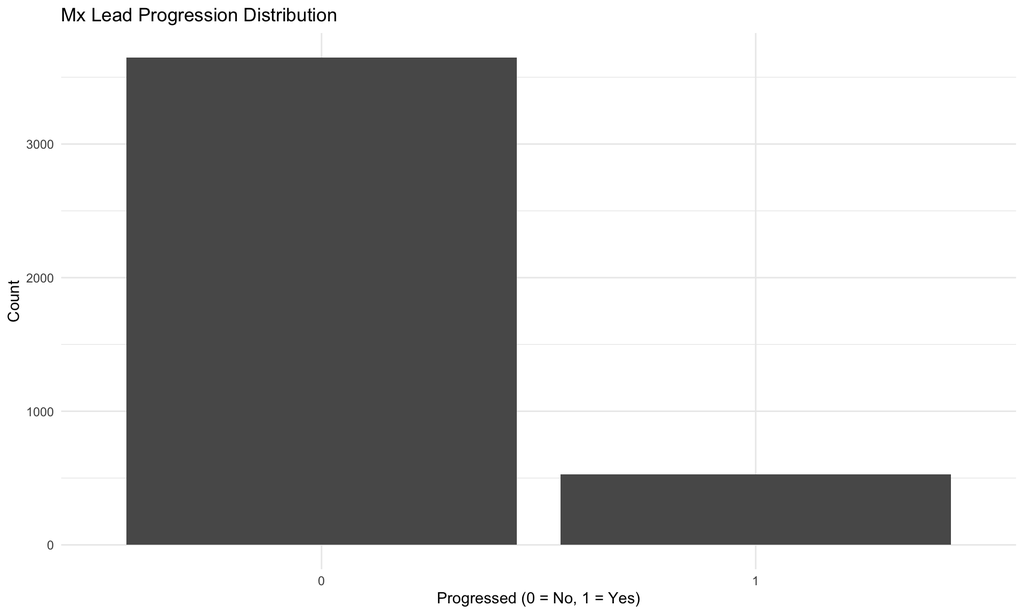

```r
library(ggplot2)
library(scales)

ggplot(mx_data, aes(x = factor(progressed))) +
  geom_bar() +
  labs(title = "Mx Lead Progression Distribution",
       x = "Progressed (0 = No, 1 = Yes)",
       y = "Count") +
  theme_minimal()
```

## 7.1 Step 2 — Applying stability rule (avoid tiny segments)

*this sets a minimum volume threshold so the conclusions are stable.*

```r
MIN_N <- 200
```

## 7.2 Step 3 — Interaction EDA: Industry × Tier (Mx only)

*This is the first “ICP cluster” view.*

```r
library(dplyr)

mx_industry_tier <- mx_data %>%
  group_by(acct_target_industry, acct_tier_rollup) %>%
  summarise(
    Total_Leads = n(),
    Conversions = sum(progressed),
    Conversion_Rate = mean(progressed),
    .groups = "drop"
  ) %>%
  filter(Total_Leads >= MIN_N) %>%
  arrange(desc(Conversion_Rate))

mx_industry_tier
```

| acct_target_industry | acct_tier_rollup | Total_Leads | Conversions | Conversion_Rate |
| --- | --- | --- | --- | --- |
| Medical Device | Small | 202 | 45 | 0.22277228 |
| Pharma & BioTech | Small | 354 | 72 | 0.20338983 |
| Medical Device | Medium | 598 | 93 | 0.15551839 |
| Non-Life Science | Medium | 593 | 81 | 0.13659359 |
| Pharma & BioTech | Medium | 1311 | 145 | 0.11060259 |
| Non-Life Science | Small | 325 | 27 | 0.08307692 |
| Pharma & BioTech | Large | 331 | 23 | 0.06948640 |

*Visualization: Heatmap*

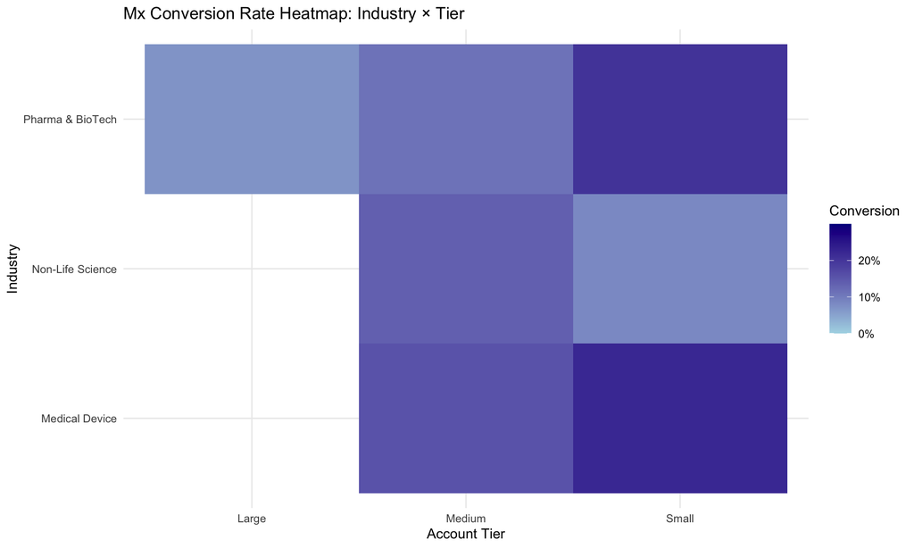

```r
ggplot(mx_industry_tier,
       aes(x = acct_tier_rollup,
           y = acct_target_industry,
           fill = Conversion_Rate)) +
  geom_tile() +
  scale_fill_gradient(
    low = "lightblue",
    high = "darkblue",
    limits = c(0, 0.30),
    labels = scales::percent
  ) +
  labs(title = "Mx Conversion Rate Heatmap: Industry × Tier",
       x = "Account Tier",
       y = "Industry",
       fill = "Conversion") +
  theme_minimal()
```

## 7.3 Step 4 — Interaction EDA: Manufacturing Model × Industry (Mx only)

```r
mx_mfg_industry <- mx_data %>%
  group_by(acct_manufacturing_model, acct_target_industry) %>%
  summarise(
    Total_Leads = n(),
    Conversions = sum(progressed),
    Conversion_Rate = mean(progressed),
    .groups = "drop"
  ) %>%
  filter(Total_Leads >= MIN_N) %>%
  arrange(desc(Conversion_Rate))

mx_mfg_industry
```

| acct_manufacturing_model | acct_target_industry | Total_Leads | Conversions | Conversion_Rate |
| --- | --- | --- | --- | --- |
| In-House | Non-Life Science | 394 | 65 | 0.16497462 |
| In-House | Medical Device | 577 | 89 | 0.15424610 |
| CDMO | Pharma & BioTech | 371 | 50 | 0.13477089 |
| In-House | Pharma & BioTech | 865 | 96 | 0.11098266 |
| Not Enough Info Found | Pharma & BioTech | 213 | 8 | 0.03755869 |

*Visualization*

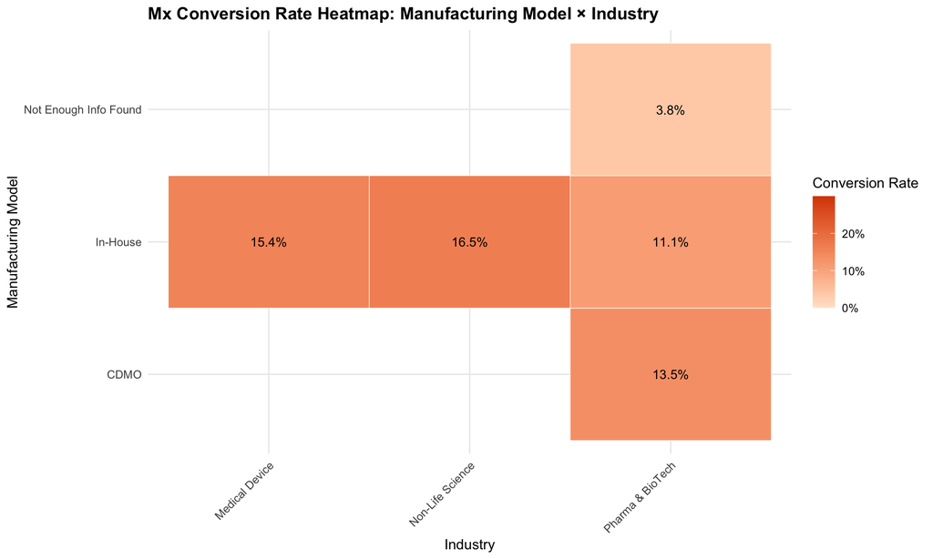

```r
library(scales)

ggplot(mx_mfg_industry,
       aes(x = acct_target_industry,
           y = acct_manufacturing_model,
           fill = Conversion_Rate)) +

  geom_tile(color = "white") +

  geom_text(aes(label = percent(Conversion_Rate, accuracy = 0.1)),
            size = 3.5,
            color = "black") +

  scale_fill_gradient(
    low = "#FFE5D0",        # light peach
    high = "#D94801",       # strong orange
    limits = c(0, 0.30),    # fixed 0%–30% scale
    labels = percent
  ) +

  labs(title = "Mx Conversion Rate Heatmap: Manufacturing Model × Industry",
       x = "Industry",
       y = "Manufacturing Model",
       fill = "Conversion Rate") +

  theme_minimal() +
  theme(
    axis.text.x = element_text(angle = 45, hjust = 1),
    plot.title = element_text(face = "bold")
  )
```

## 7.4 Step 5 — Quick “Top Segments” table (Rate + Opportunity)

*This prevents from recommending tiny high-rate segments.*

```r
mx_industry_tier <- mx_industry_tier %>%
  mutate(Opportunity_Score = Conversion_Rate * log1p(Total_Leads)) %>%
  arrange(desc(Opportunity_Score))

head(mx_industry_tier, 10)
```

| acct_target_industry | acct_tier_rollup | Total_Leads | Conversions | Conversion_Rate | Opportunity_Score |
| --- | --- | --- | --- | --- | --- |
| Pharma & BioTech | Small | 354 | 72 | 0.20338983 | 1.1943290 |
| Medical Device | Small | 202 | 45 | 0.22277228 | 1.1836350 |
| Medical Device | Medium | 598 | 93 | 0.15551839 | 0.9945808 |
| Non-Life Science | Medium | 593 | 81 | 0.13659359 | 0.8724068 |
| Pharma & BioTech | Medium | 1311 | 145 | 0.11060259 | 0.7940501 |
| Non-Life Science | Small | 325 | 27 | 0.08307692 | 0.4807576 |
| Pharma & BioTech | Large | 331 | 23 | 0.06948640 | 0.4033780 |

# 8 6.2 TITLE ANALYSIS (Buyer Persona Layer)

So far, we have analyzed accounts.

now will see within strong account segments, who actually converts?

## 8.1 Step 1: Create Seniority

```r
mx_data$title_lower <- tolower(mx_data$contact_lead_title)

mx_data$seniority <- ifelse(grepl("chief|ceo|cfo|cio|cto|coo|president", mx_data$title_lower), "C-Level",
                      ifelse(grepl("vp|vice president", mx_data$title_lower), "VP",
                      ifelse(grepl("director|head", mx_data$title_lower), "Director",
                      ifelse(grepl("manager|lead", mx_data$title_lower), "Manager",
                      "Other"))))
```

*Analyze:*

```r
aggregate(progressed ~ seniority, data = mx_data, mean)
```

| seniority | progressed |
| --- | --- |
| C-Level | 0.1365047 |
| Director | 0.0982906 |
| Manager | 0.1461233 |
| Other | 0.1142563 |
| VP | 0.1785714 |

*Visualization:*

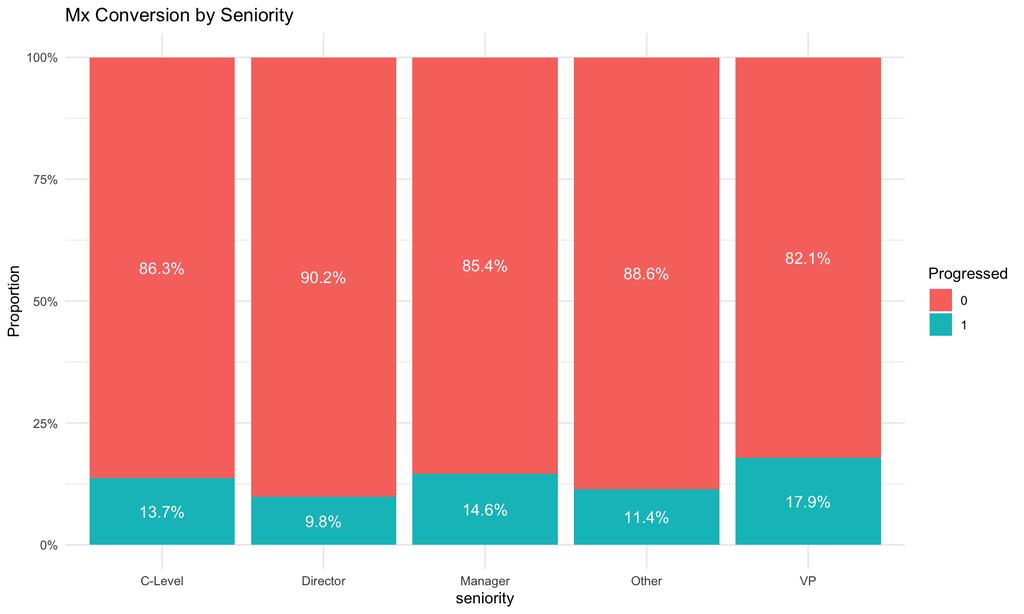

```r
mx_data %>%
  count(seniority, progressed) %>%
  group_by(seniority) %>%
  mutate(prop = n / sum(n)) %>%
  ggplot(aes(x = seniority,
             y = prop,
             fill = factor(progressed))) +

  geom_bar(stat = "identity", position = "fill") +

  geom_text(aes(label = percent(prop, accuracy = 0.1)),
            position = position_fill(vjust = 0.5),
            color = "white",
            size = 4) +

  scale_y_continuous(labels = percent) +

  labs(title = "Mx Conversion by Seniority",
       y = "Proportion",
       fill = "Progressed") +

  theme_minimal()
```

## 8.2 Step 2: Create Functional Area

```r
mx_data$function_band <- ifelse(grepl("quality|qa|qc", mx_data$title_lower), "Quality",
                         ifelse(grepl("manufactur|production|plant", mx_data$title_lower), "Manufacturing",
                         ifelse(grepl("operation|ops", mx_data$title_lower), "Operations",
                         ifelse(grepl("regulator|compliance", mx_data$title_lower), "Regulatory",
                         ifelse(grepl("engineer|process", mx_data$title_lower), "Engineering",
                         "Other")))))
```

*Aggrigate*

```r
library(dplyr)

function_summary <- mx_data %>%
  group_by(function_band) %>%
  summarise(
    Total_Leads = n(),
    Conversions = sum(progressed),
    Conversion_Rate = mean(progressed),
    .groups = "drop"
  ) %>%
  arrange(desc(Conversion_Rate))

function_summary
```

| function_band | Total_Leads | Conversions | Conversion_Rate |
| --- | --- | --- | --- |
| Quality | 745 | 118 | 0.15838926 |
| Engineering | 281 | 42 | 0.14946619 |
| Manufacturing | 406 | 57 | 0.14039409 |
| Other | 2307 | 270 | 0.11703511 |
| Regulatory | 90 | 10 | 0.11111111 |
| Operations | 349 | 32 | 0.09169054 |

*Visualization:*

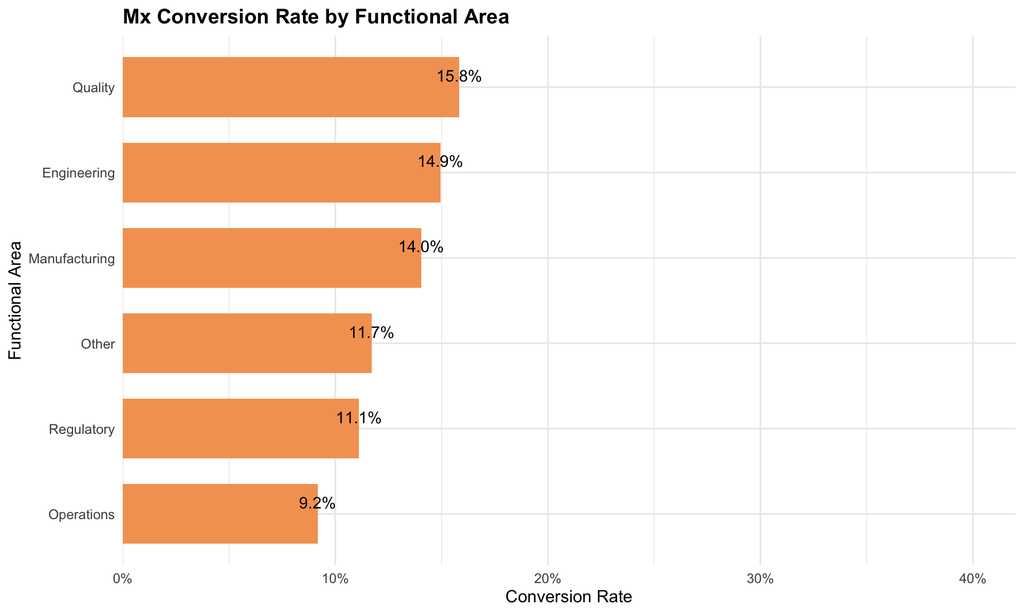

```r
library(ggplot2)
library(scales)

ggplot(function_summary,
       aes(x = reorder(function_band, Conversion_Rate),
           y = Conversion_Rate)) +

  geom_col(fill = "#F4A261", width = 0.7) +

  geom_text(aes(label = percent(Conversion_Rate, accuracy = 0.1)),
            vjust = -0.5,
            size = 4) +

  scale_y_continuous(labels = percent,
                     limits = c(0, 0.40),
                     expand = expansion(mult = c(0, 0.05))) +

  coord_flip() +

  labs(title = "Mx Conversion Rate by Functional Area",
       x = "Functional Area",
       y = "Conversion Rate") +

  theme_minimal(base_size = 12) +
  theme(plot.title = element_text(face = "bold"))
```

*Viz -2*

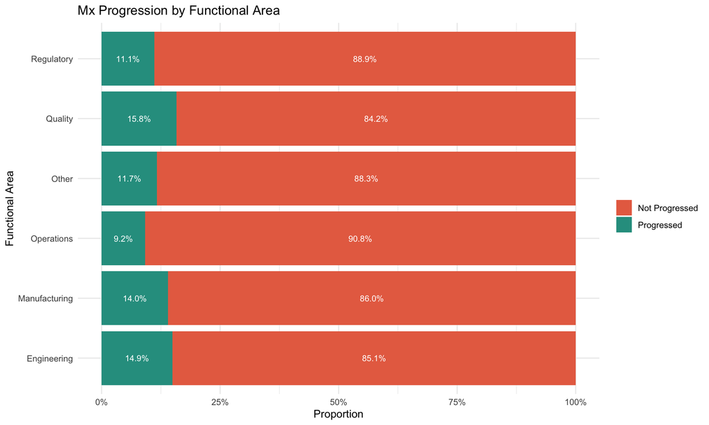

```r
mx_data %>%
  count(function_band, progressed) %>%
  group_by(function_band) %>%
  mutate(prop = n / sum(n)) %>%

  ggplot(aes(x = function_band,
             y = prop,
             fill = factor(progressed))) +

  geom_bar(stat = "identity", position = "fill") +

  geom_text(aes(label = percent(prop, accuracy = 0.1)),
            position = position_fill(vjust = 0.5),
            size = 3,
            color = "white") +

  scale_y_continuous(labels = percent) +

  scale_fill_manual(values = c("#E76F51", "#2A9D8F"),
                    labels = c("Not Progressed", "Progressed")) +

  coord_flip() +

  labs(title = "Mx Progression by Functional Area",
       x = "Functional Area",
       y = "Proportion",
       fill = "") +

  theme_minimal()
```

## 8.3 LEVEL 3 — CROSS-SELL OPPORTUNITIES

```r
cross_sell <- aggregate(progressed ~ acct_target_industry + solution_rollup,
                        data = qal_data,
                        mean)
```

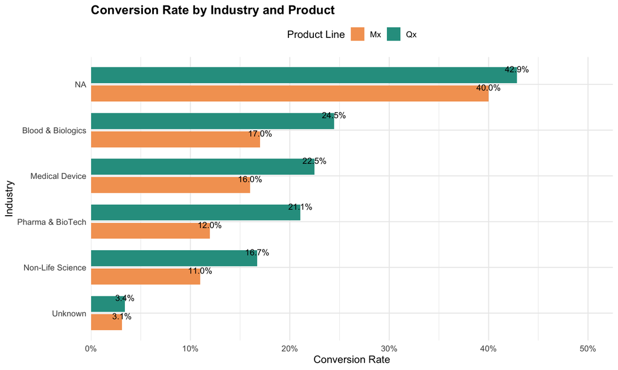

```r
library(dplyr)
library(ggplot2)
library(scales)

industry_conv <- qal_data %>%
  group_by(solution_rollup, acct_target_industry) %>%
  summarise(conv_rate = mean(progressed),
            total = n(),
            .groups = "drop")

ggplot(industry_conv,
       aes(x = reorder(acct_target_industry, conv_rate),
           y = conv_rate,
           fill = solution_rollup)) +

  geom_col(position = position_dodge(width = 0.8),
           width = 0.7) +

  geom_text(aes(label = percent(conv_rate, accuracy = 0.1)),
            position = position_dodge(width = 0.8),
            vjust = -0.5,
            size = 3.5) +

  scale_y_continuous(labels = percent,
                     limits = c(0, 0.5),
                     expand = expansion(mult = c(0, 0.05))) +

  scale_fill_manual(values = c(
    "Ax" = "#6C8EBF",
    "Mx" = "#F4A261",
    "Qx" = "#2A9D8F"
  )) +

  labs(title = "Conversion Rate by Industry and Product",
       x = "Industry",
       y = "Conversion Rate",
       fill = "Product Line") +

  coord_flip() +

  theme_minimal(base_size = 12) +
  theme(
    plot.title = element_text(face = "bold"),
    legend.position = "top"
  )
```

# 9 6.3 Strategic EDA

*What is the Ideal Account + Ideal Persona combination for Mx?*

## 9.1 STEP 1 — Combine Seniority + Function

```r
library(dplyr)

persona_summary <- mx_data %>%
  group_by(seniority, function_band) %>%
  summarise(
    Total_Leads = n(),
    Conversion_Rate = mean(progressed),
    .groups = "drop"
  ) %>%
  filter(Total_Leads >= 100) %>%
  arrange(desc(Conversion_Rate))

persona_summary
```

| seniority | function_band | Total_Leads | Conversion_Rate |
| --- | --- | --- | --- |
| Manager | Manufacturing | 128 | 0.19531250 |
| Other | Quality | 227 | 0.16740088 |
| C-Level | Quality | 168 | 0.16071429 |
| C-Level | Other | 434 | 0.15898618 |
| Manager | Quality | 296 | 0.14527027 |
| Manager | Other | 393 | 0.13486005 |
| Other | Manufacturing | 112 | 0.13392857 |
| Other | Engineering | 163 | 0.12269939 |
| C-Level | Manufacturing | 126 | 0.10317460 |
| Other | Other | 1386 | 0.10173160 |

[output cut: 2 more lines]

## 9.2 STEP 2 — Overlay Account Segment + Persona

```r
mx_data %>%
  group_by(acct_target_industry,
           acct_tier_rollup,
           function_band) %>%
  summarise(
    n = n(),
    conv = mean(progressed),
    .groups = "drop"
  ) %>%
  filter(n >= 200) %>%
  arrange(desc(conv))
```

| acct_target_industry | acct_tier_rollup | function_band | n | conv |
| --- | --- | --- | --- | --- |
| Pharma & BioTech | Small | Other | 220 | 0.21818182 |
| Medical Device | Medium | Other | 245 | 0.17142857 |
| Pharma & BioTech | Medium | Quality | 276 | 0.14130435 |
| Non-Life Science | Medium | Other | 412 | 0.12135922 |
| Pharma & BioTech | Medium | Other | 631 | 0.09350238 |
| Non-Life Science | Small | Other | 253 | 0.05928854 |

## 9.3 STEP 3 — Build a Priority Score

```r
library(dplyr)

persona_summary <- mx_data %>%
  group_by(seniority, function_band) %>%
  summarise(
    Total_Leads = n(),
    Conversions = sum(progressed),
    Conversion_Rate = mean(progressed),
    .groups = "drop"
  ) %>%
  filter(Total_Leads >= 50)

persona_scored <- persona_summary %>%
  mutate(
    priority_score = Conversion_Rate * log1p(Total_Leads)
  ) %>%
  arrange(desc(priority_score))


persona_scored
```

| seniority | function_band | Total_Leads | Conversions | Conversion_Rate | priority_score |
| --- | --- | --- | --- | --- | --- |
| Manager | Engineering | 53 | 14 | 0.26415094 | 1.0536939 |
| C-Level | Other | 434 | 69 | 0.15898618 | 0.9658960 |
| Manager | Manufacturing | 128 | 25 | 0.19531250 | 0.9491821 |
| Other | Quality | 227 | 38 | 0.16740088 | 0.9088772 |
| Manager | Quality | 296 | 43 | 0.14527027 | 0.8271300 |
| C-Level | Quality | 168 | 27 | 0.16071429 | 0.8244480 |
| Manager | Other | 393 | 53 | 0.13486005 | 0.8059710 |
| Other | Other | 1386 | 141 | 0.10173160 | 0.7360178 |
| Other | Manufacturing | 112 | 15 | 0.13392857 | 0.6331323 |
| Other | Engineering | 163 | 20 | 0.12269939 | 0.6257505 |

[output cut: 4 more lines]

*Visualization*

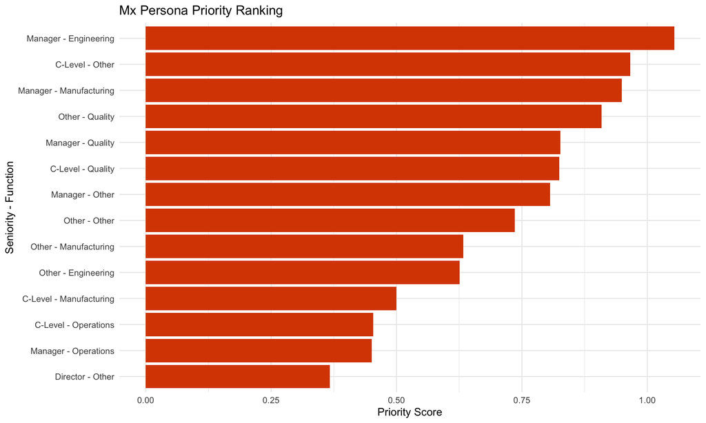

```r
library(ggplot2)
library(scales)

ggplot(persona_scored,
       aes(x = reorder(paste(seniority, function_band, sep = " - "),
                       priority_score),
           y = priority_score)) +

  geom_col(fill = "#D94801") +

  coord_flip() +

  labs(title = "Mx Persona Priority Ranking",
       x = "Seniority - Function",
       y = "Priority Score") +

  theme_minimal()
```

## 9.4 STEP 4 — Cross-Sell Overlay

*Which profiles perform well for BOTH Qx and Mx?*

```r
qal_data$title_lower <- tolower(qal_data$contact_lead_title)

qal_data$seniority <- ifelse(grepl("chief|ceo|cfo|cio|cto|coo|president", qal_data$title_lower), "C-Level",
                      ifelse(grepl("vp|vice president", qal_data$title_lower), "VP",
                      ifelse(grepl("director|head", qal_data$title_lower), "Director",
                      ifelse(grepl("manager|lead", qal_data$title_lower), "Manager",
                      "Other"))))

qal_data$function_band <- ifelse(grepl("quality|qa|qc", qal_data$title_lower), "Quality",
                          ifelse(grepl("manufactur|production|plant", qal_data$title_lower), "Manufacturing",
                          ifelse(grepl("operation|ops", qal_data$title_lower), "Operations",
                          ifelse(grepl("regulator|compliance", qal_data$title_lower), "Regulatory",
                          ifelse(grepl("engineer|process", qal_data$title_lower), "Engineering",
                          "Other")))))


cross_sell_persona <- qal_data %>%
  group_by(solution_rollup, function_band) %>%
  summarise(
    Total_Leads = n(),
    Conversion_Rate = mean(progressed),
    .groups = "drop"
  ) %>%
  arrange(desc(Conversion_Rate))

cross_sell_persona
```

| solution_rollup | function_band | Total_Leads | Conversion_Rate |
| --- | --- | --- | --- |
| Qx | Operations | 408 | 0.27696078 |
| Qx | Quality | 3245 | 0.26348228 |
| Qx | Engineering | 440 | 0.25227273 |
| Qx | Regulatory | 326 | 0.19325153 |
| Qx | Manufacturing | 302 | 0.16556291 |
| Qx | Other | 7745 | 0.16358941 |
| Mx | Quality | 745 | 0.15838926 |
| Mx | Engineering | 281 | 0.14946619 |
| Mx | Manufacturing | 406 | 0.14039409 |
| Mx | Other | 2307 | 0.11703511 |

[output cut: 2 more lines]

*Viz-1. Cross-Sell Heatmap (Best Visual Insight)*

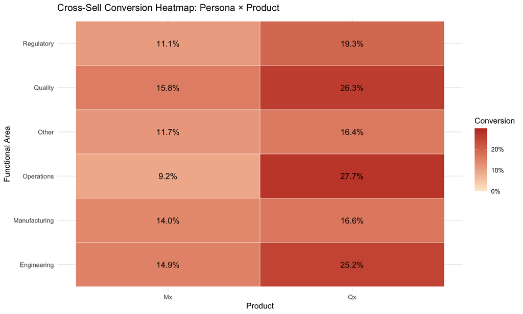

```r
library(dplyr)
library(ggplot2)
library(scales)

cross_sell_persona <- qal_data %>%
  group_by(solution_rollup, function_band) %>%
  summarise(
    Conversion_Rate = mean(progressed),
    .groups = "drop"
  )

ggplot(cross_sell_persona,
       aes(x = solution_rollup,
           y = function_band,
           fill = Conversion_Rate)) +

  geom_tile(color = "white") +

  geom_text(aes(label = percent(Conversion_Rate, accuracy = 0.1)),
            color = "black",
            size = 4) +

  scale_fill_gradient(
    low = "#FDEBD0",
    high = "#C0392B",
    limits = c(0, 0.30),
    labels = percent
  ) +

  labs(title = "Cross-Sell Conversion Heatmap: Persona × Product",
       x = "Product",
       y = "Functional Area",
       fill = "Conversion") +

  theme_minimal()
```

*Viz-2 Side-by-Side Bar Comparison.*

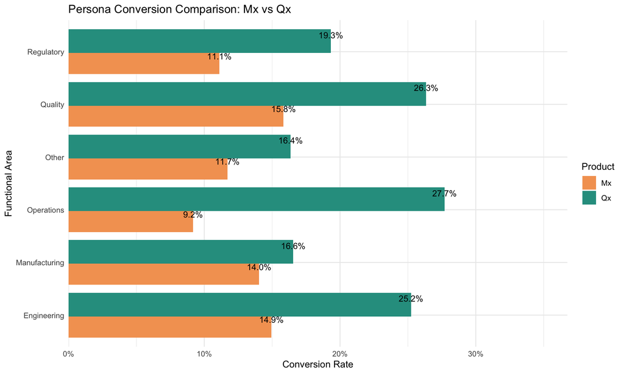

```r
ggplot(cross_sell_persona,
       aes(x = function_band,
           y = Conversion_Rate,
           fill = solution_rollup)) +

  geom_col(position = position_dodge(width = 0.8)) +

  geom_text(aes(label = scales::percent(Conversion_Rate, accuracy = 0.1)),
            position = position_dodge(width = 0.8),
            vjust = -0.5,
            size = 3.5) +

  scale_y_continuous(labels = scales::percent,
                     limits = c(0, 0.35),
                     expand = expansion(mult = c(0, 0.05))) +

  scale_fill_manual(values = c(
    "Ax" = "#6C8EBF",
    "Mx" = "#F4A261",
    "Qx" = "#2A9D8F"
  )) +

  coord_flip() +

  labs(title = "Persona Conversion Comparison: Mx vs Qx",
       x = "Functional Area",
       y = "Conversion Rate",
       fill = "Product") +

  theme_minimal()
```

```r
library(rcompanion)
library(dplyr)

vars <- c("acct_target_industry",
          "acct_manufacturing_model",
          "acct_tier_rollup",
          "acct_territory_rollup",
          "function_band",
          "seniority")

cramer_results <- sapply(vars, function(v) {

  # Ensure variable exists
  if (!v %in% names(qal_data)) return(NA)

  # Create contingency table
  tbl <- table(qal_data[[v]], qal_data$progressed)

  # Remove zero rows
  tbl <- tbl[rowSums(tbl) > 0, , drop = FALSE]

  # Compute Cramer's V
  cramerV(tbl)
})

cramer_df <- data.frame(
  Variable = vars,
  Cramers_V = round(cramer_results, 3)
) %>%
  arrange(desc(Cramers_V))

cramer_df
```

|  | Variable | Cramers_V |
| --- | --- | --- |
| acct_manufacturing_model.Cramer V | acct_manufacturing_model | 0.130 |
| seniority.Cramer V | seniority | 0.106 |
| function_band.Cramer V | function_band | 0.101 |
| acct_tier_rollup.Cramer V | acct_tier_rollup | 0.090 |
| acct_target_industry.Cramer V | acct_target_industry | 0.068 |
| acct_territory_rollup.Cramer V | acct_territory_rollup | 0.051 |

*Viz-4*

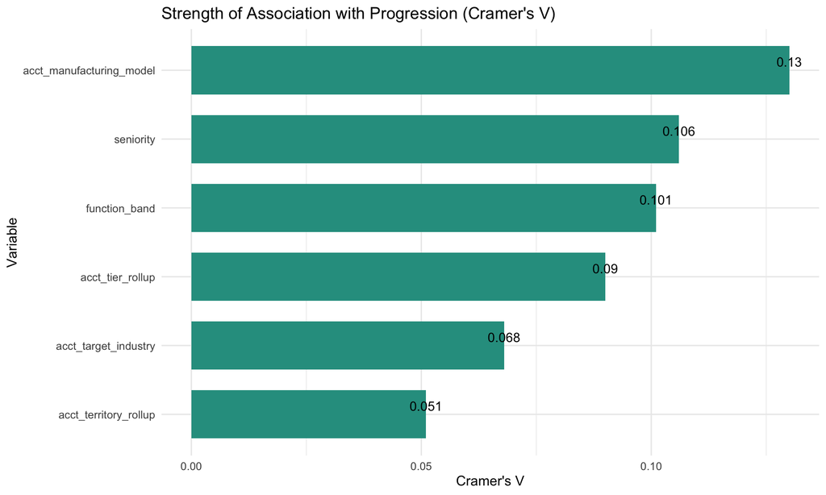

```r
ggplot(cramer_df,
       aes(x = reorder(Variable, Cramers_V),
           y = Cramers_V)) +

  geom_col(fill = "#2A9D8F", width = 0.7) +

  geom_text(aes(label = Cramers_V),
            vjust = -0.4,
            size = 4) +

  coord_flip() +

  labs(title = "Strength of Association with Progression (Cramer's V)",
       x = "Variable",
       y = "Cramer's V") +

  theme_minimal(base_size = 12)
```

Value Interpretation

0.00–0.10 Weak 0.10–0.30 Moderate 0.30 Strong

# 10 7. Conclusion: Exploratory Data Analysis Findings

This exploratory analysis was conducted to understand which types of accounts and buyer profiles are most likely to progress in the MasterControl QAL pipeline, with particular attention to the underperformance of Mx compared to Qx.

Overall Product Performance

The analysis confirms that Qx consistently achieves higher progression rates than Mx. This validates the business concern that Mx requires more focused targeting and segmentation to improve performance.

### 10.0.1 *Level 1: Account Analysis*

Among all account-level variables examined, manufacturing model emerged as the strongest driver of progression. It showed a substantially higher association with progression compared to industry, tier, or territory.

Accounts operating under in-house or contract manufacturing models demonstrated stronger progression behavior than services or consulting-focused organizations. This suggests that how a company manufactures is more predictive of engagement than the industry label alone.

In practical terms, manufacturing structure should be the primary segmentation axis for account targeting.

### 10.0.3 *Level 3: Cross-Sell Opportunities*

When comparing Mx and Qx across personas and account segments, several interesting patterns emerged.

Certain functional roles perform well across both products, indicating potential universal high-converting profiles. In other cases, segments that convert strongly for Qx show weaker performance for Mx, suggesting untapped cross-sell potential.

This cross-product comparison highlights opportunities to leverage existing Qx success patterns to strengthen Mx positioning within similar account structures.

### 10.0.4 *Integrated Insight*

Bringing these findings together, the most promising Mx prospects tend to share the following characteristics:

[output not shown]

Manufacturing model appears to be the primary driver, with persona characteristics acting as an important refinement layer.

### 10.0.5 *Final Implications*

This EDA establishes a clear, data-supported direction for improving Mx targeting strategy:

[output not shown]

The dataset is now well-prepared for the next stage, which may include predictive modeling or structured lead scoring to further validate and operationalize these findings.